# Homework 2

```r
# e.g.tuned max_depth for series1 is 3 and for series2 is 2
best_max_depth[[1]]
best_max_depth[[2]]
```

```
Parameter tuning of 'rpart':

- sampling method: 10-fold cross validation

- best parameters:
 minsplit cp minbucket maxdepth
       20  0        10        3

- best performance: 0.1707118
```

```
Parameter tuning of 'rpart':

- sampling method: 10-fold cross validation

- best parameters:
 minsplit cp minbucket maxdepth
       20  0        10        2

- best performance: 0.2005034
```

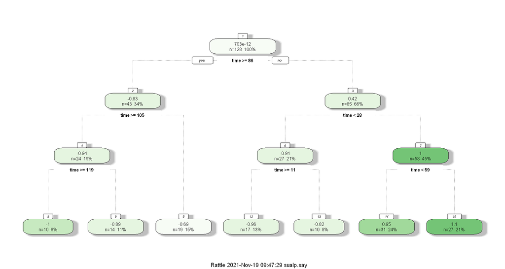

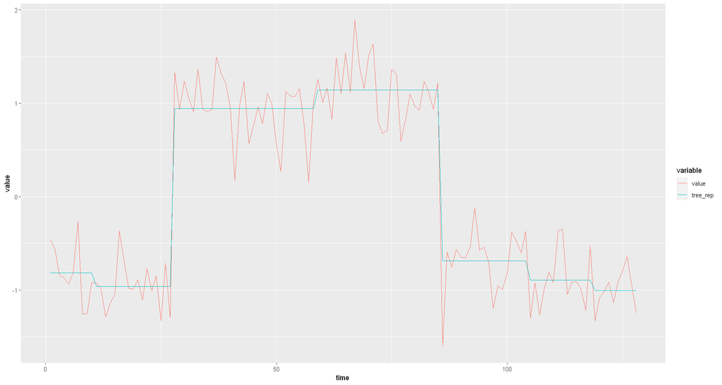

```r
# plot results of series1
sample_series = long_cbf[id==1]
fancyRpartPlot(tree_representation_list[[1]])
sample_series[,tree_rep:=predict(tree_representation_list[[1]], sample_series)]

data_plot=melt(sample_series, id.vars='time', measure.vars=c('value','tree_rep'))

ggplot(data_plot,aes(x=time,y=value,color=variable))+
    geom_line()
```

*3- One you have completed the previous tasks, you have the information of the best parameter settings for each approach. After you obtain the representation for each time series (using the best parameters), you can calculate the approximation error (i.e. mean squared error for each series – 30 MSE values for CBF set). Compare the error rates using the boxplot of MSE values for each approach. Comment on your findings.*

```r
fitted_values = list()

for (series in c(1:30)) {

    selected_series = long_cbf[id==series]

    # fit values with regression tree
    selected_series[,tree_rep:=predict(tree_representation_list[[series]], selected_series)]

    # fit values with fusedlasso
    selected_series[,fusedlasso_rep:=predict(fusedlasso_representation_list[[series]],  lambda=min_lambda[[series]], selected_series)$fit]

    #list fitted values
    fitted_values[[series]] = selected_series

}

head(fitted_values[[1]])
```

| id | class | time | value | tree_rep | fusedlasso_rep |
| --- | --- | --- | --- | --- | --- |
| 1 | 1 | 1 | -0.4642765 | -0.8172091 | -0.7505869 |
| 1 | 1 | 2 | -0.5550479 | -0.8172091 | -0.7505869 |
| 1 | 1 | 3 | -0.8428431 | -0.8172091 | -0.7505869 |
| 1 | 1 | 4 | -0.8658955 | -0.8172091 | -0.7505869 |
| 1 | 1 | 5 | -0.9363963 | -0.8172091 | -0.7505869 |
| 1 | 1 | 6 | -0.8172700 | -0.8172091 | -0.7505869 |

```r
fitted_values_dt = do.call(rbind, fitted_values)
```

```r
mse = melt(fitted_values_dt, id.vars=c("id", "class","time"), measure.vars=c("value","tree_rep","fusedlasso_rep"))
mse = merge(mse, long_cbf[,list(id, class, time, obs=value)], by=c("id",  "class", "time"))
```

```r
head(mse)
```

| id | class | time | variable | value | obs |
| --- | --- | --- | --- | --- | --- |
| 1 | 1 | 1 | value | -0.4642765 | -0.4642765 |
| 1 | 1 | 1 | tree_rep | -0.8172091 | -0.4642765 |
| 1 | 1 | 1 | fusedlasso_rep | -0.7505869 | -0.4642765 |
| 1 | 1 | 2 | value | -0.5550479 | -0.5550479 |
| 1 | 1 | 2 | tree_rep | -0.8172091 | -0.5550479 |
| 1 | 1 | 2 | fusedlasso_rep | -0.7505869 | -0.5550479 |

```r
mse_final = mse[!(variable=="value"), list(mse=mean((value-obs)^2)),list(id, class, variable)]
head(mse_final)
```

| id | class | variable | mse |
| --- | --- | --- | --- |
| 1 | 1 | tree_rep | 0.08737098 |
| 1 | 1 | fusedlasso_rep | 0.07102399 |
| 2 | 1 | tree_rep | 0.10458403 |
| 2 | 1 | fusedlasso_rep | 0.10601782 |
| 3 | 1 | tree_rep | 0.09406769 |
| 3 | 1 | fusedlasso_rep | 0.07415701 |

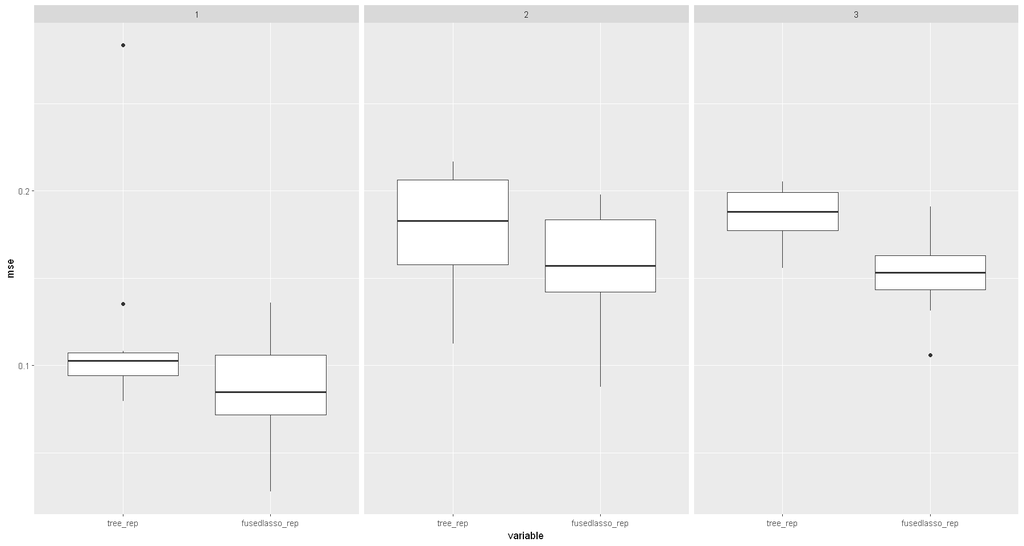

```r
ggplot(mse_final, aes(x=variable,y=mse)) + facet_wrap(~class) + geom_boxplot()
```

###### From the boxplots above, one can understood that fusedlasso representation worked better than tree represenation for all 3 classes. This is not suprising result since fusedlasso representation covers the more variance information. Furthermore, there are 2 series belong to Class1 where tree representation did so much error. Except for the first class, variance of the MSEs are nearly equal for both approach.

*4- Assume that we would like to perform a comparison based on the accuracy of 1-NN classifier on the representations. Compare the accuracy of 1-NN classifier on the training data when you use the raw time series as input versus the representations. You can use Euclidean distance to calculate the distance between the time series.*

```r
install.packages("shiny", type="binary")
install.packages("manipulateWidget")
install.packages("TSclust")
```

[output not shown]

[output not shown]

```
installing the source package 'manipulateWidget'
```

```r
require(TSclust)
```

```r
# raw time series as input
matrix_cbf = as.matrix(cbf[,2:130])
rownames(matrix_cbf) = matrix_cbf[,129]

# calculate Euclidean distance between series
distance_matrix = as.matrix(diss(matrix_cbf, METHOD="EUCL"))

# make distance from i to i infinitely big number
distance_matrix[distance_matrix==0] = 9999

l1 <- apply(distance_matrix, 2, which.min)
l2 <- apply(distance_matrix, 2, min)

result_raw = data.frame(series = colnames(distance_matrix),
                        nearest_neighbour = rownames(distance_matrix)[l1],
                        distance = l2)

result_raw = merge(result_raw, cbf[,list(nearest_neighbour = id, predicted  = class)], by="nearest_neighbour")
result_raw = merge(result_raw, cbf[,list(series = id, actual = class)], by="series")
result_raw$correctly_classified = ifelse(result_raw$predicted==result_raw$actual, 1, 0)
```

```r
result_raw
```

| series | nearest_neighbour | distance | predicted | actual | correctly_classified |
| --- | --- | --- | --- | --- | --- |
| 1 | 2 | 9.502131 | 1 | 1 | 1 |
| 10 | 7 | 6.810550 | 1 | 1 | 1 |
| 11 | 12 | 9.714184 | 2 | 2 | 1 |
| 12 | 11 | 9.714184 | 2 | 2 | 1 |
| 13 | 19 | 11.471707 | 1 | 1 | 1 |
| 14 | 9 | 10.091123 | 2 | 2 | 1 |
| 15 | 17 | 8.239273 | 2 | 2 | 1 |
| 16 | 19 | 10.515787 | 1 | 3 | 0 |
| 17 | 15 | 8.239273 | 2 | 2 | 1 |
| 18 | 22 | 8.588959 | 2 | 2 | 1 |
| 19 | 23 | 8.845968 | 1 | 1 | 1 |
| 2 | 7 | 9.020564 | 1 | 1 | 1 |
| 20 | 26 | 13.698227 | 3 | 3 | 1 |
| 21 | 17 | 10.910319 | 2 | 2 | 1 |
| 22 | 18 | 8.588959 | 2 | 2 | 1 |
| 23 | 19 | 8.845968 | 1 | 1 | 1 |
| 24 | 19 | 10.093331 | 1 | 1 | 1 |
| 25 | 29 | 9.095617 | 3 | 3 | 1 |
| 26 | 25 | 9.162740 | 3 | 3 | 1 |
| 27 | 25 | 10.752989 | 3 | 2 | 0 |
| 28 | 26 | 9.200928 | 3 | 3 | 1 |
| 29 | 25 | 9.095617 | 3 | 3 | 1 |
| 3 | 1 | 9.570280 | 1 | 1 | 1 |
| 30 | 25 | 9.732957 | 3 | 1 | 0 |
| 4 | 3 | 10.778981 | 1 | 3 | 0 |
| 5 | 15 | 12.269778 | 2 | 2 | 1 |
| 6 | 3 | 9.886737 | 1 | 2 | 0 |
| 7 | 10 | 6.810550 | 1 | 1 | 1 |
| 8 | 4 | 11.075225 | 3 | 3 | 1 |
| 9 | 14 | 10.091123 | 2 | 2 | 1 |

```r
# change long format to wide format to calculate distances
tree_rep = reshape(fitted_values_dt[,c("id","time", "tree_rep")], idvar = "id", timevar = "time", direction = "wide")
colnames(tree_rep)=gsub("tree_rep.", "V", names(tree_rep))
```

```r
head(tree_rep)
```

| id | V1 | V2 | V3 | V4 | V5 | V6 | V7 | V8 | V9 | ... | V119 | V120 | V121 | V122 | V123 | V124 | V125 | V126 | V127 | V128 |
| --- | --- | --- | --- | --- | --- | --- | --- | --- | --- | --- | --- | --- | --- | --- | --- | --- | --- | --- | --- | --- |
| 1 | -0.8172091 | -0.8172091 | -0.8172091 | -0.8172091 | -0.8172091 | -0.8172091 | -0.8172091 | -0.8172091 | -0.8172091 | ... | -1.0040189 | -1.0040189 | -1.0040189 | -1.0040189 | -1.0040189 | -1.0040189 | -1.0040189 | -1.0040189 | -1.0040189 | -1.0040189 |
| 2 | -1.1613113 | -1.1613113 | -1.1613113 | -1.1613113 | -1.1613113 | -1.1613113 | -1.1613113 | -1.1613113 | -1.1613113 | ... | -1.1181994 | -1.1181994 | -1.1181994 | -1.1181994 | -1.1181994 | -1.1181994 | -1.1181994 | -1.1181994 | -1.1181994 | -1.1181994 |
| 3 | -0.6339440 | -0.6339440 | -0.6339440 | -0.6339440 | -0.6339440 | -0.6339440 | -0.6339440 | -0.6339440 | -0.6339440 | ... | -0.6500975 | -0.6500975 | -0.6500975 | -0.6500975 | -0.6500975 | -0.6500975 | -0.6500975 | -0.6500975 | -0.6500975 | -0.6500975 |
| 4 | -0.6452374 | -0.6452374 | -0.6452374 | -0.6452374 | -0.6452374 | -0.6452374 | -0.6452374 | -0.6452374 | -0.6452374 | ... | -0.4331929 | -0.4331929 | -0.4331929 | -0.4331929 | -0.4331929 | -0.4331929 | -0.4331929 | -0.4331929 | -0.4331929 | -0.4331929 |
| 5 | -0.9195566 | -0.9195566 | -0.9195566 | -0.9195566 | -0.9195566 | -0.9195566 | -0.9195566 | -0.9195566 | -0.9195566 | ... | -1.2017353 | -1.2017353 | -1.2017353 | -1.2017353 | -1.2017353 | -1.2017353 | -1.2017353 | -1.2017353 | -1.2017353 | -1.2017353 |
| 6 | -0.5593072 | -0.5593072 | -0.5593072 | -0.5593072 | -0.5593072 | -0.5593072 | -0.5593072 | -0.5593072 | -0.5593072 | ... | -0.4056573 | -0.4056573 | -0.4056573 | -0.4056573 | -0.4056573 | -0.4056573 | -0.4056573 | -0.4056573 | -0.4056573 | -0.4056573 |

```r
# tree representation as input
matrix_cbf = as.matrix(tree_rep)
rownames(matrix_cbf) = matrix_cbf[,1]

# calculate Euclidean distance between series
distance_matrix = as.matrix(diss(matrix_cbf, METHOD="EUCL"))

# make distance from i to i infinitely big number
distance_matrix[distance_matrix==0] = 9999

l1 <- apply(distance_matrix, 2, which.min)
l2 <- apply(distance_matrix, 2, min)

result_tree = data.frame(series = colnames(distance_matrix),
                        nearest_neighbour = rownames(distance_matrix)[l1],
                        distance = l2)

result_tree = merge(result_tree, cbf[,list(nearest_neighbour = id, predicted  = class)], by="nearest_neighbour")
result_tree = merge(result_tree, cbf[,list(series = id, actual = class)], by="series")
result_tree$correctly_classified = ifelse(result_tree$predicted==result_tree$actual, 1, 0)
```

```r
result_tree
```

| series | nearest_neighbour | distance | predicted | actual | correctly_classified |
| --- | --- | --- | --- | --- | --- |
| 1 | 2 | 7.970707 | 1 | 1 | 1 |
| 10 | 7 | 4.565689 | 1 | 1 | 1 |
| 11 | 12 | 5.196083 | 2 | 2 | 1 |
| 12 | 11 | 5.196083 | 2 | 2 | 1 |
| 13 | 19 | 10.130468 | 1 | 1 | 1 |
| 14 | 9 | 7.636176 | 2 | 2 | 1 |
| 15 | 17 | 5.022345 | 2 | 2 | 1 |
| 16 | 19 | 8.621130 | 1 | 3 | 0 |
| 17 | 15 | 5.022345 | 2 | 2 | 1 |
| 18 | 22 | 5.575498 | 2 | 2 | 1 |
| 19 | 23 | 6.796856 | 1 | 1 | 1 |
| 2 | 7 | 7.176167 | 1 | 1 | 1 |
| 20 | 25 | 11.959312 | 3 | 3 | 1 |
| 21 | 17 | 8.949267 | 2 | 2 | 1 |
| 22 | 18 | 5.575498 | 2 | 2 | 1 |
| 23 | 19 | 6.796856 | 1 | 1 | 1 |
| 24 | 23 | 8.698637 | 1 | 1 | 1 |
| 25 | 26 | 6.056879 | 3 | 3 | 1 |
| 26 | 28 | 5.615833 | 3 | 3 | 1 |
| 27 | 25 | 8.254290 | 3 | 2 | 0 |
| 28 | 26 | 5.615833 | 3 | 3 | 1 |
| 29 | 28 | 5.851338 | 3 | 3 | 1 |
| 3 | 6 | 7.299274 | 2 | 1 | 0 |
| 30 | 25 | 7.937589 | 3 | 1 | 0 |
| 4 | 3 | 8.296230 | 1 | 3 | 0 |
| 5 | 15 | 10.401523 | 2 | 2 | 1 |
| 6 | 3 | 7.299274 | 1 | 2 | 0 |
| 7 | 10 | 4.565689 | 1 | 1 | 1 |
| 8 | 4 | 8.451458 | 3 | 3 | 1 |
| 9 | 14 | 7.636176 | 2 | 2 | 1 |

```r
# change long format to wide format to calculate distances
fusedlasso_rep = reshape(fitted_values_dt[,c("id","time", "fusedlasso_rep")], idvar = "id", timevar = "time", direction = "wide")
colnames(fusedlasso_rep)=gsub("fusedlasso_rep.", "V", names(fusedlasso_rep))
```

```r
head(fusedlasso_rep)
```

| id | V1 | V2 | V3 | V4 | V5 | V6 | V7 | V8 | V9 | ... | V119 | V120 | V121 | V122 | V123 | V124 | V125 | V126 | V127 | V128 |
| --- | --- | --- | --- | --- | --- | --- | --- | --- | --- | --- | --- | --- | --- | --- | --- | --- | --- | --- | --- | --- |
| 1 | -0.7505869 | -0.7505869 | -0.7505869 | -0.7505869 | -0.7505869 | -0.7505869 | -0.7505869 | -0.9745224 | -0.9745224 | ... | -0.9531423 | -0.9531423 | -0.9531423 | -0.9531423 | -0.9531423 | -0.9531423 | -0.9531423 | -0.9531423 | -0.9531423 | -0.9531423 |
| 2 | -1.0647598 | -1.0647598 | -1.0647598 | -1.0647598 | -1.0647598 | -1.0647598 | -1.0647598 | -1.0647598 | -1.0647598 | ... | -1.1491790 | -1.1491790 | -1.1491790 | -1.1491790 | -1.1491790 | -1.1491790 | -1.1491790 | -1.1491790 | -1.1491790 | -1.1491790 |
| 3 | -0.5013410 | -0.5013410 | -0.5013410 | -0.5013410 | -0.5013410 | -0.5013410 | -0.5013410 | -0.6247595 | -0.6247595 | ... | -0.6799623 | -0.6799623 | -0.6799623 | -0.6799623 | -0.6799623 | -0.6799623 | -0.6799623 | -0.6799623 | -0.6799623 | -0.6799623 |
| 4 | -0.6698067 | -0.6698067 | -0.6698067 | -0.6698067 | -0.6698067 | -0.6698067 | -0.6698067 | -0.6698067 | -0.6698067 | ... | -0.4690187 | -0.4690187 | -0.4690187 | -0.4690187 | -0.4690187 | -0.4690187 | -0.4690187 | -0.4690187 | -0.4690187 | -0.4690187 |
| 5 | -1.0927387 | -1.0927387 | -1.0927387 | -0.9361692 | -0.9361692 | -0.9361692 | -0.9361692 | -0.9361692 | -0.9361692 | ... | -1.1088608 | -1.1088608 | -1.1088608 | -1.1088608 | -1.1088608 | -1.1088608 | -1.1088608 | -1.1088608 | -1.1088608 | -1.1088608 |
| 6 | -0.5003466 | -0.5003466 | -0.5003466 | -0.5003466 | -0.5003466 | -0.5003466 | -0.5003466 | -0.5003466 | -0.5003466 | ... | -0.4375492 | -0.4375492 | -0.4375492 | -0.4375492 | -0.4375492 | -0.4375492 | -0.4375492 | -0.4375492 | -0.4375492 | -0.4375492 |

```r
# fusedlasso representation as input
matrix_cbf = as.matrix(fusedlasso_rep)
rownames(matrix_cbf) = matrix_cbf[,1]

# calculate Euclidean distance between series
distance_matrix = as.matrix(diss(matrix_cbf, METHOD="EUCL"))

# make distance from i to i infinitely big number
distance_matrix[distance_matrix==0] = 9999

l1 <- apply(distance_matrix, 2, which.min)
l2 <- apply(distance_matrix, 2, min)

result_lasso = data.frame(series = colnames(distance_matrix),
                          nearest_neighbour = rownames(distance_matrix)[l1],
                          distance = l2)

result_lasso = merge(result_lasso, cbf[,list(nearest_neighbour = id, predicted  = class)], by="nearest_neighbour")
result_lasso = merge(result_lasso, cbf[,list(series = id, actual = class)], by="series")
result_lasso$correctly_classified = ifelse(result_lasso$predicted==result_lasso$actual, 1, 0)
```

```r
result_lasso
```

| series | nearest_neighbour | distance | predicted | actual | correctly_classified |
| --- | --- | --- | --- | --- | --- |
| 1 | 2 | 7.591761 | 1 | 1 | 1 |
| 10 | 7 | 4.890237 | 1 | 1 | 1 |
| 11 | 12 | 5.211631 | 2 | 2 | 1 |
| 12 | 11 | 5.211631 | 2 | 2 | 1 |
| 13 | 19 | 9.183602 | 1 | 1 | 1 |
| 14 | 9 | 6.940210 | 2 | 2 | 1 |
| 15 | 17 | 4.487575 | 2 | 2 | 1 |
| 16 | 19 | 8.549495 | 1 | 3 | 0 |
| 17 | 15 | 4.487575 | 2 | 2 | 1 |
| 18 | 22 | 5.321199 | 2 | 2 | 1 |
| 19 | 23 | 6.607656 | 1 | 1 | 1 |
| 2 | 7 | 6.756734 | 1 | 1 | 1 |
| 20 | 26 | 11.636064 | 3 | 3 | 1 |
| 21 | 24 | 8.370974 | 1 | 2 | 0 |
| 22 | 18 | 5.321199 | 2 | 2 | 1 |
| 23 | 19 | 6.607656 | 1 | 1 | 1 |
| 24 | 21 | 8.370974 | 2 | 1 | 0 |
| 25 | 26 | 5.627463 | 3 | 3 | 1 |
| 26 | 28 | 4.647927 | 3 | 3 | 1 |
| 27 | 25 | 7.789585 | 3 | 2 | 0 |
| 28 | 26 | 4.647927 | 3 | 3 | 1 |
| 29 | 28 | 5.380824 | 3 | 3 | 1 |
| 3 | 6 | 6.939299 | 2 | 1 | 0 |
| 30 | 25 | 7.816156 | 3 | 1 | 0 |
| 4 | 8 | 7.836198 | 3 | 3 | 1 |
| 5 | 15 | 10.182883 | 2 | 2 | 1 |
| 6 | 3 | 6.939299 | 1 | 2 | 0 |
| 7 | 10 | 4.890237 | 1 | 1 | 1 |
| 8 | 4 | 7.836198 | 3 | 3 | 1 |
| 9 | 14 | 6.940210 | 2 | 2 | 1 |

```r
# accuracy when raw time series as input
sum(result_raw$correctly_classified)/nrow(result_raw)
```

0.833333333333333

```r
# accuracy when tree representation as input
sum(result_tree$correctly_classified)/nrow(result_tree)
```

0.8

```r
# accuracy when fusedlasso representation as input
sum(result_lasso$correctly_classified)/nrow(result_lasso)
```

0.766666666666667

###### Since represenations do not carry the all information about the series, we observed decresing accuracy compared to using raw time series as training data